# Projet Série Temporelle

SCHULTZ Martin - Master SISE - Université Lyon 2  
Janvier 2023

Utilisation des librairies nécessaires

```r
library("readxl")
library("forecast")
library("fpp2")
library("ggplot2")
library("dplyr")
library("xlsx")
```

## Importation des données

```r
data = read_excel("Elec-train.xlsx")
```

La fréquence est de 96 car les données ont été mesuré toutes les 15min.  
1jour = 96 * 15min

```r
data=mutate(data, Timestamp = as.POSIXct(Timestamp,format = "%m/%d/%Y %H:%M"))
elec<- ts(data[,2], start = c(1,6), end = c(47,96),frequency = 96)
elecTemperature=ts(data[,2:3], start = c(1,6), end = c(48,96),frequency = 96)
```

## Analyse des donénes

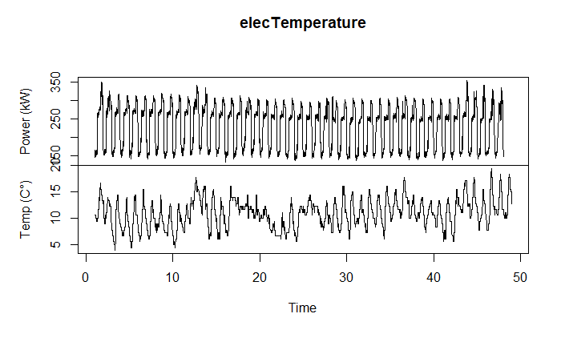

```r
plot(elecTemperature)
```

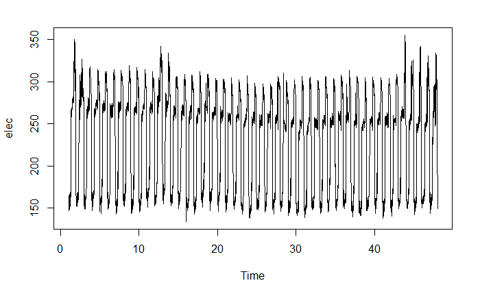

```r
plot(elec)
```

Il semble avoir une saisonnalité dans la consommation électrique, Mais il ne semble pas qu’il existe une tendance, car la consommation électrique ne semble ni augmenter ni diminiuer.

## Division des données en échantillons d’apprentissage et de test.

L’échantillon de test représente le dernier jour de consommation.

```r
elec_train = window(elec, start=c(1,6), end=c(46,96))
elec_test = window(elec, start=c(47,1), end=c(47,96))
elec_prev = window(elec, start=c(1,6))

elecTemperature_train = window(elecTemperature, start=c(1,6), end=c(46,96))
elecTemperature_test = window(elecTemperature, start=c(47,1), end=c(47,96))
elecTemperature_prev = window(elecTemperature, start=c(1,6))
```

On commence la série à partir de 6 car la première valeur à été prise à 1h15. (6ième quarts-heure de la journée)

# Sans Utilisation de la variable Temperature

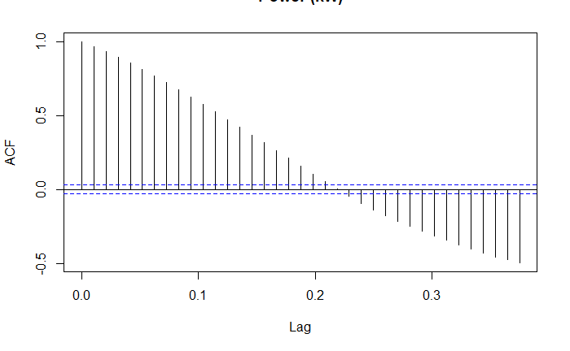

```r
tmp=acf(elec_train,type="cor",plot = FALSE)
plot(tmp)
```

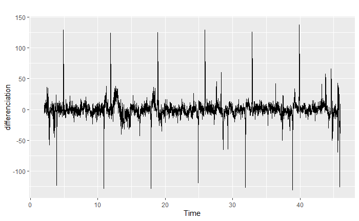

```r
differenciation=diff(elec_train,lag=96)
autoplot(differenciation)
```

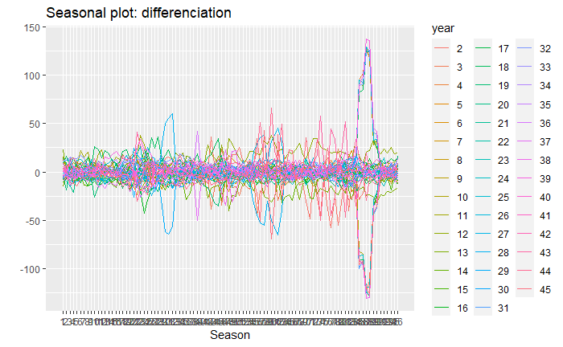

```r
ggseasonplot(differenciation)
```

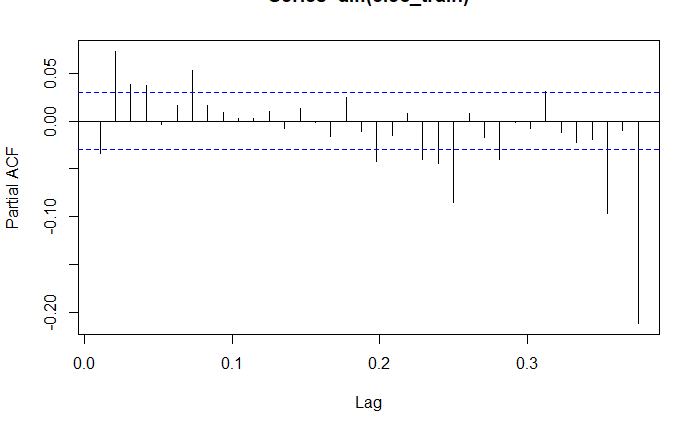

```r
diffpacf=pacf(diff(elec_train),type="cor",plot = FALSE)
plot(diffpacf)
```

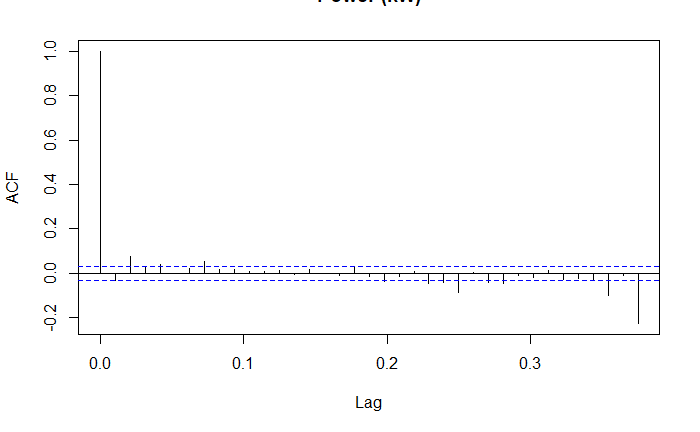

```r
diffacf=acf(diff(elec_train),type="cor",plot = FALSE)
plot(diffacf)
```